# Final Project STA 141A

Emily Callahan

2023-05-07

Abstract In this project I will analyise the Data set from Steinmetz’s 2019 experiment, “Sensory coding and the causal impact of mouse cortex in a visual decision”, exploring how the amount of sessions and parts of the brain used in a trial can affect the final outcome of the success rate.

Introduction In this report questions about Steinmetz’s 2019 experiment, “Sensory coding and the causal impact of mouse cortex in a visual decision”. Why did some mice use less parts of their brain? Does the amount of brain parts used affect the success rate? Using variables such as mouse_name (the name of the mouse for specific sessions), data_exp (the date of the experiment), n_brain_area(the unique brain area involved), n_neurons (the number of neurons), n_trials (the number of trials in each session), and success_rate( the ratio of successful trials to the total number of trials), visuals will be displayed answering questions such as, Do the amount of sessions affect the success rate? and Is using more parts of the brain related to a higher success rate?

Exploratory analysis Part 1 i.)

| mouse_name | date_exp | n_brain_area | n_neurons | n_trials | success_rate |
| --- | --- | --- | --- | --- | --- |
| Cori | 2016-12-14 | 8 | 734 | 114 | 0.61 |
| Cori | 2016-12-17 | 5 | 1070 | 251 | 0.63 |
| Cori | 2016-12-18 | 11 | 619 | 228 | 0.66 |
| Forssmann | 2017-11-01 | 11 | 1769 | 249 | 0.67 |
| Forssmann | 2017-11-02 | 10 | 1077 | 254 | 0.66 |
| Forssmann | 2017-11-04 | 5 | 1169 | 290 | 0.74 |
| Forssmann | 2017-11-05 | 8 | 584 | 252 | 0.67 |
| Hench | 2017-06-15 | 15 | 1157 | 250 | 0.64 |
| Hench | 2017-06-16 | 12 | 788 | 372 | 0.69 |
| Hench | 2017-06-17 | 13 | 1172 | 447 | 0.62 |
| Hench | 2017-06-18 | 6 | 857 | 342 | 0.80 |
| Lederberg | 2017-12-05 | 12 | 698 | 340 | 0.74 |
| Lederberg | 2017-12-06 | 15 | 983 | 300 | 0.80 |
| Lederberg | 2017-12-07 | 10 | 756 | 268 | 0.69 |
| Lederberg | 2017-12-08 | 8 | 743 | 404 | 0.76 |
| Lederberg | 2017-12-09 | 6 | 474 | 280 | 0.72 |
| Lederberg | 2017-12-10 | 6 | 565 | 224 | 0.83 |
| Lederberg | 2017-12-11 | 10 | 1090 | 216 | 0.81 |

```
##       ACA       CA1        DG       LGd        MB       MOs       MRN        MS
## 0.8620690 0.6176471 1.7058824 1.0733333 4.4444444 1.0652174 5.4117647 4.2173913
##        PL        RN      root       SCm       SCs     VISam        ZI
## 1.5108696 8.2758621 1.7052023 2.9333333 2.0312500 1.0882353 1.4000000
```

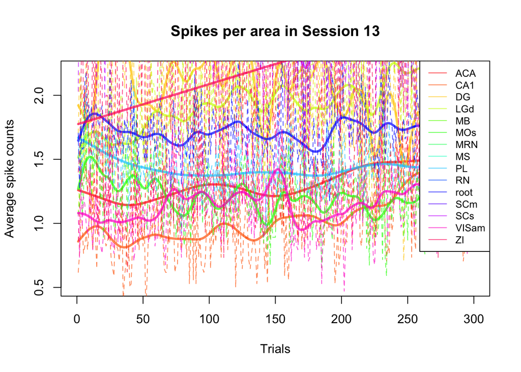

#Through the number of trials across sections you can see that each mouse was given a different amount of trials, this could affect the outcome of their success as it should be assumed they would learn the more opportunnities they are given while being tested. For example, sessions 2 and 8 were given 251 and 250 trials respectivly, and both recieve a very similar success rate of .63 and .64. #Number of Trials Accross Sessions - the bar plot shows the number of trials in each session. Differences in the number of trials across sessions indicate heterogeneity in experiemental conditions.

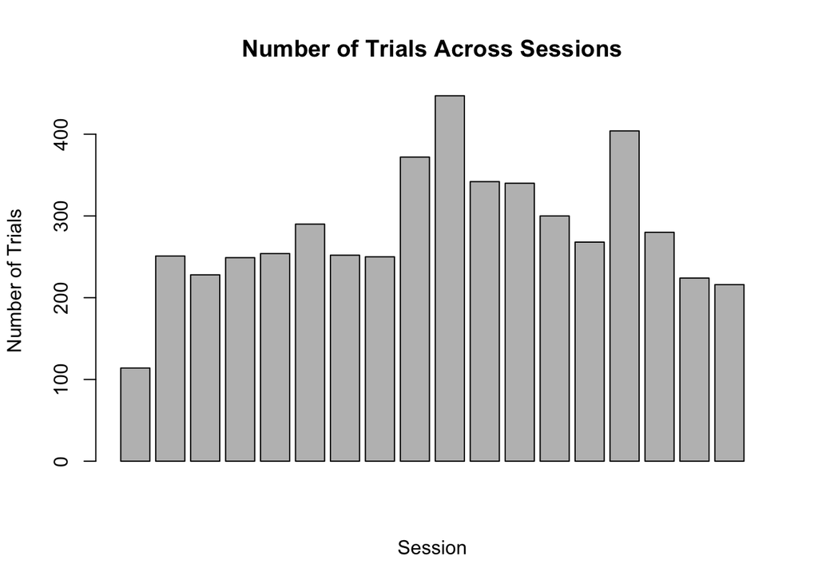

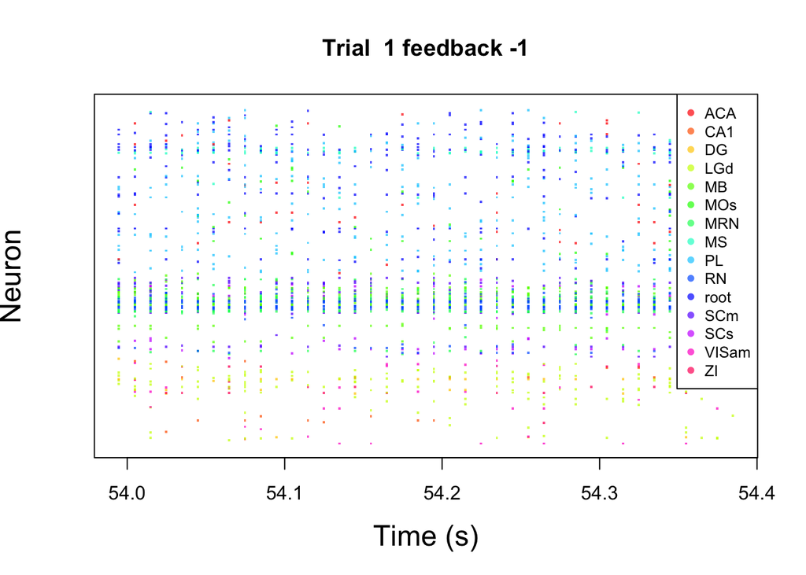

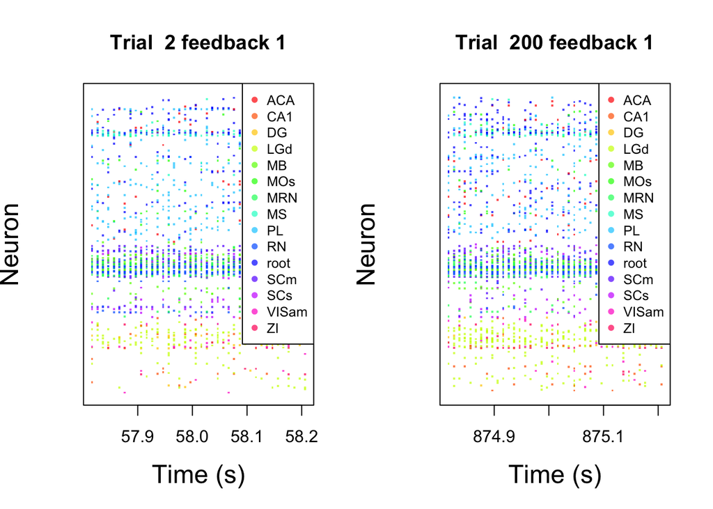

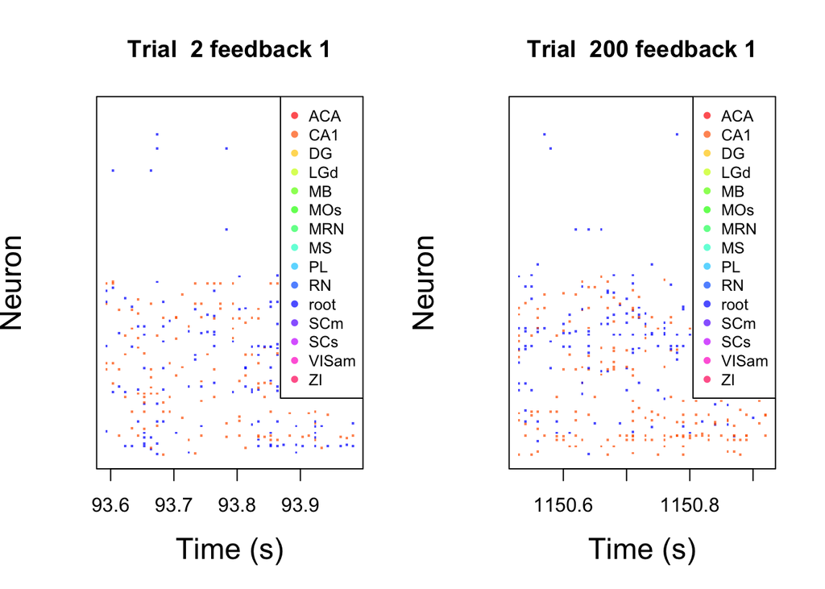

iv.) #Brain Area Distribution - the bar plot below illustrates the frequency distribution of brain areas across mice. Displaying how specific brain areas are more dominate in the records of the experiment and that certain brain areas are hardly used. This displays heterogeneity.

```
## Sessions per mouse:
```

```
##      Cori Forssmann     Hench Lederberg
##         3         4         4         7
```

```
## Brain Area Distribution:
```

```
##
##   ACA   ACB   AUD   BLA   CA1   CA3    CP    DG   EPd   GPe   ILA    LD   LGd
##   540   155   246   132   799   360   492   416    52   205   144   174   584
##    LH    LP    LS   LSc   LSr    MB    MD   MEA    MG   MOp   MOs   MRN    MS
##    18   124   139    72   475   460   126    41   137   447   585   236    23
##    NB   OLF   ORB  ORBm    OT   PAG   PIR    PL    PO   POL  POST    PT    RN
##    43   181   202   122    26    14    67   448   255   154   295    45    58
##  root   RSP    RT   SCm   SCs  SCsg    SI   SNr   SPF   SSp   SSs   SUB    TH
##  2303    85    44   116    69    19    48   130    15    74   120   423   890
##    TT  VISa VISam  VISl  VISp VISpm VISrl   VPL   VPM    ZI
##   137   243   265   434   592   302   136   301   222   245
```

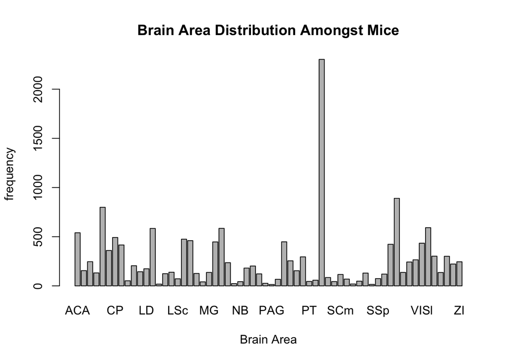

#Data integration #Part 2